# Coronavirus v Čechách

## Přehled

Základní přehled (testy)

| Datum | Přírustkový počet testů | Kumulativní počet testů | Pozitivita testů (v %) |
| --- | --- | --- | --- |
| 2020-11-16 | 26063 | 2813201 | 20.76 |
| 2020-11-17 | 17503 | 2830704 | 24.26 |
| 2020-11-18 | 24341 | 2855045 | 22.66 |
| 2020-11-19 | 26406 | 2881451 | 24.51 |
| 2020-11-20 | 23798 | 2905249 | 24.41 |

Základní přehled (nákaza)

| Datum | Přírustkový počet nakažených | Kumulativní počet nakažených | Kumulativní počet vyléčených | Kumulativní počet úmrtí |
| --- | --- | --- | --- | --- |
| 2020-11-16 | 5411 | 465521 | 388251 | 6582 |
| 2020-11-17 | 4246 | 469767 | 388507 | 6708 |
| 2020-11-18 | 5516 | 475283 | 389045 | 6843 |
| 2020-11-19 | 6471 | 481754 | 389726 | 6962 |
| 2020-11-20 | 5810 | 487564 | 390056 | 7040 |

Aktuálně hospitalizovaní: `6101`

Podíl nakažených s těžkým průběhem: `6.6`%

Smrtnost: `1.44`%

# SIR MODELY

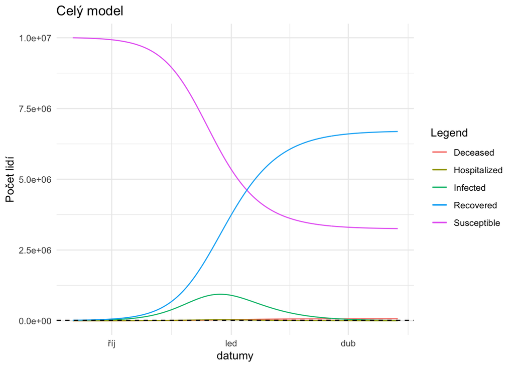

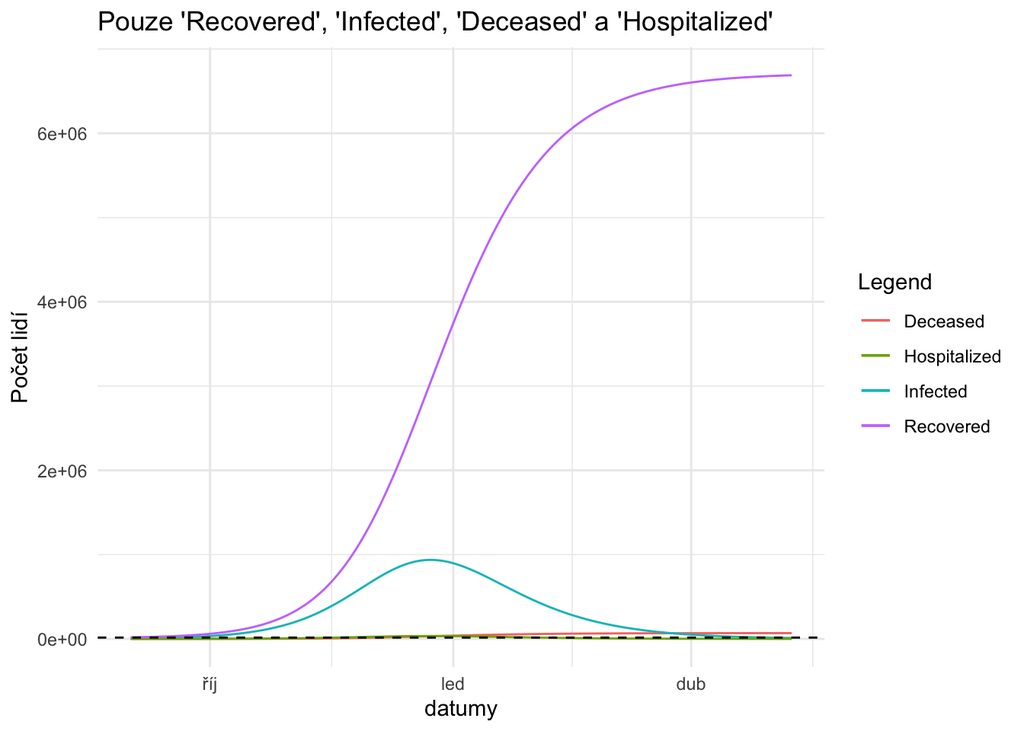

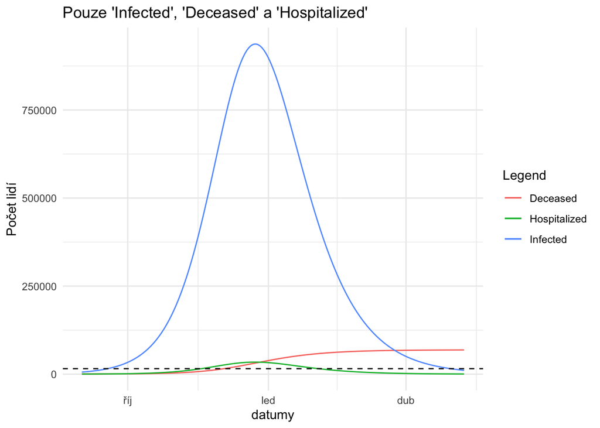

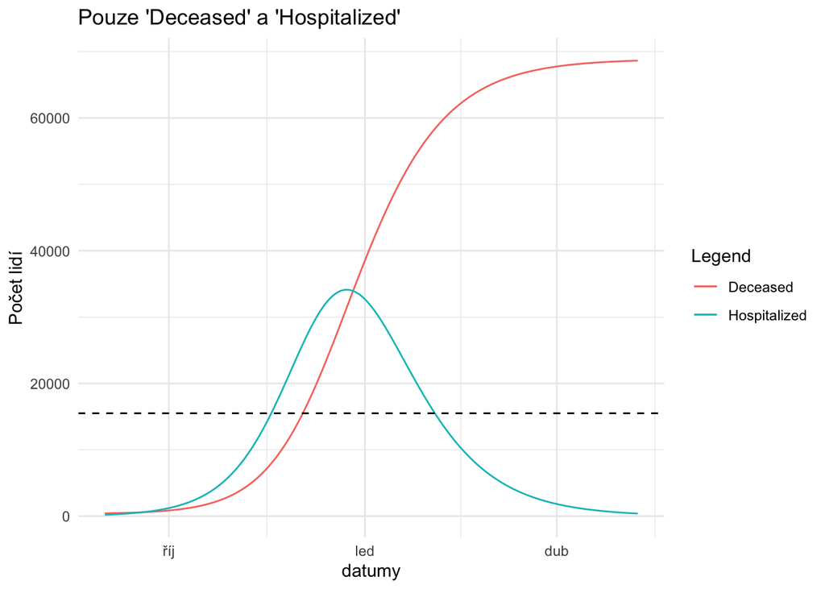

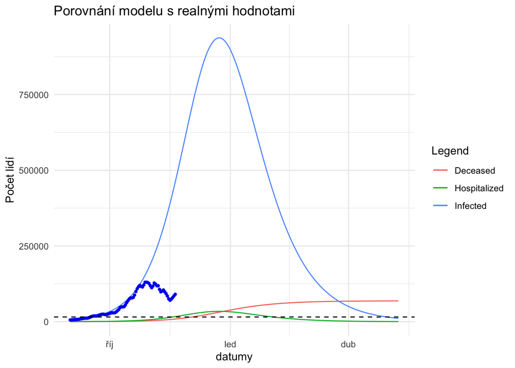

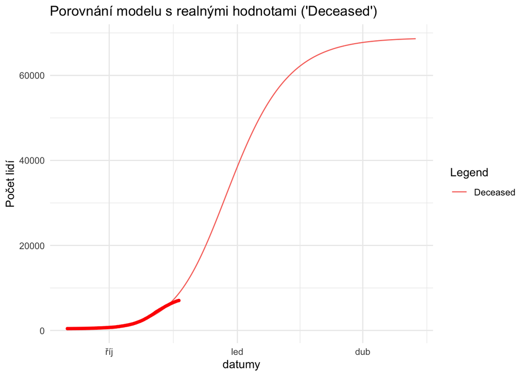

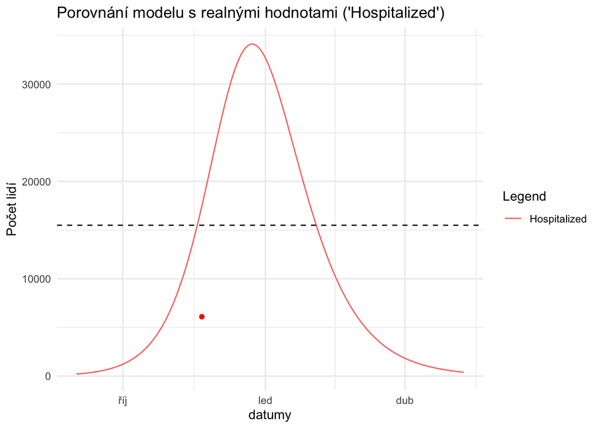

## Informace

`Peak nastane dne 2020-12-23 s počtem nakažených rovnu 937231 a aktuálním počtem hospitalizovných v nemocnicích 34115 lidí.`

`Kapacita nemocnic, která je stanovena na 15500 lůžek, bude při momentálním trendu překročena dne 2020-11-19`

`Celkově Covid-19 prodělá 6688258`

`Počet umrtí se zastaví na čísle 68637`

`Momentální hodnota rho je 1.682`

# Základní statistiky

## Testy

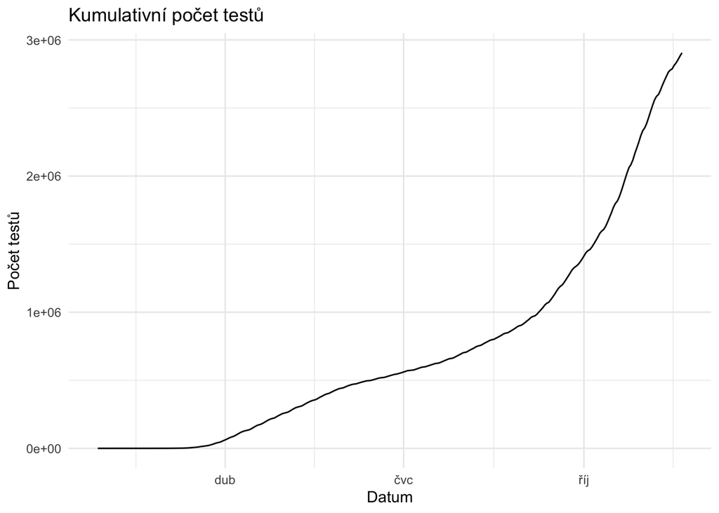

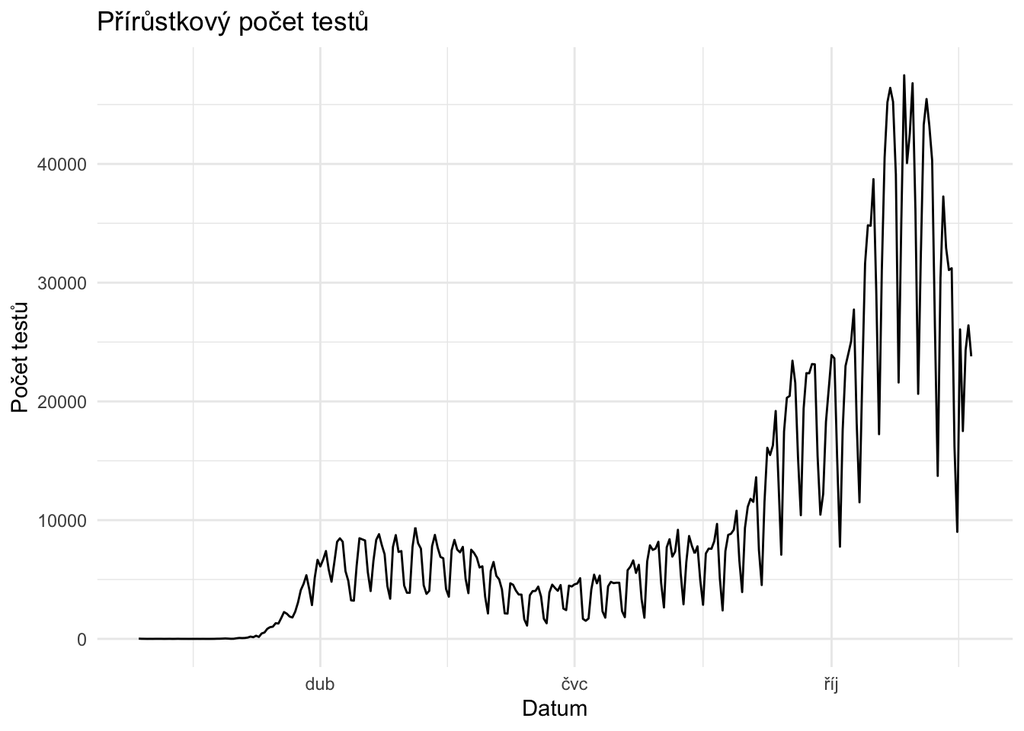

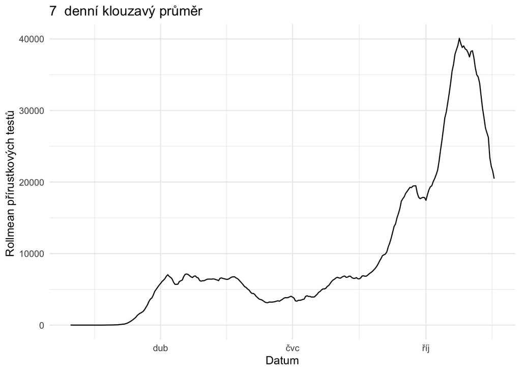

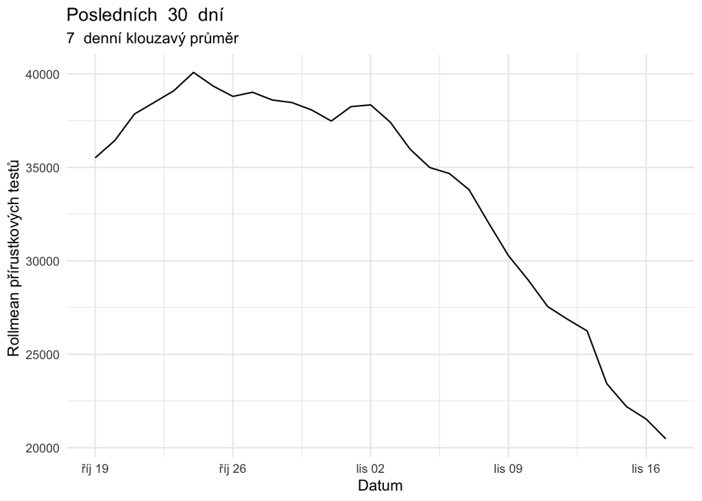

## Pozitivní případy

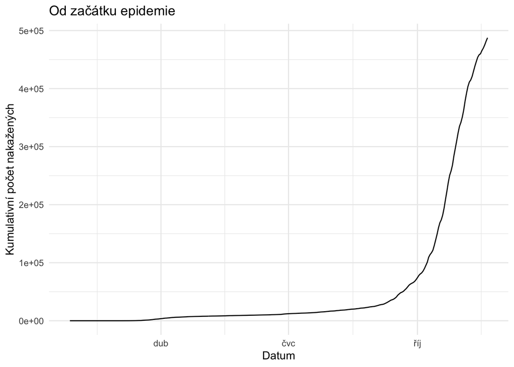

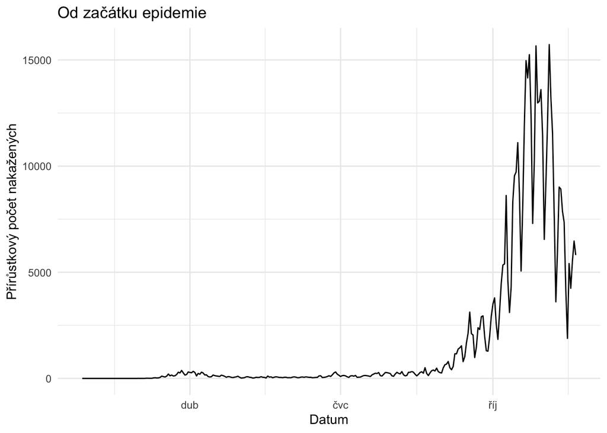

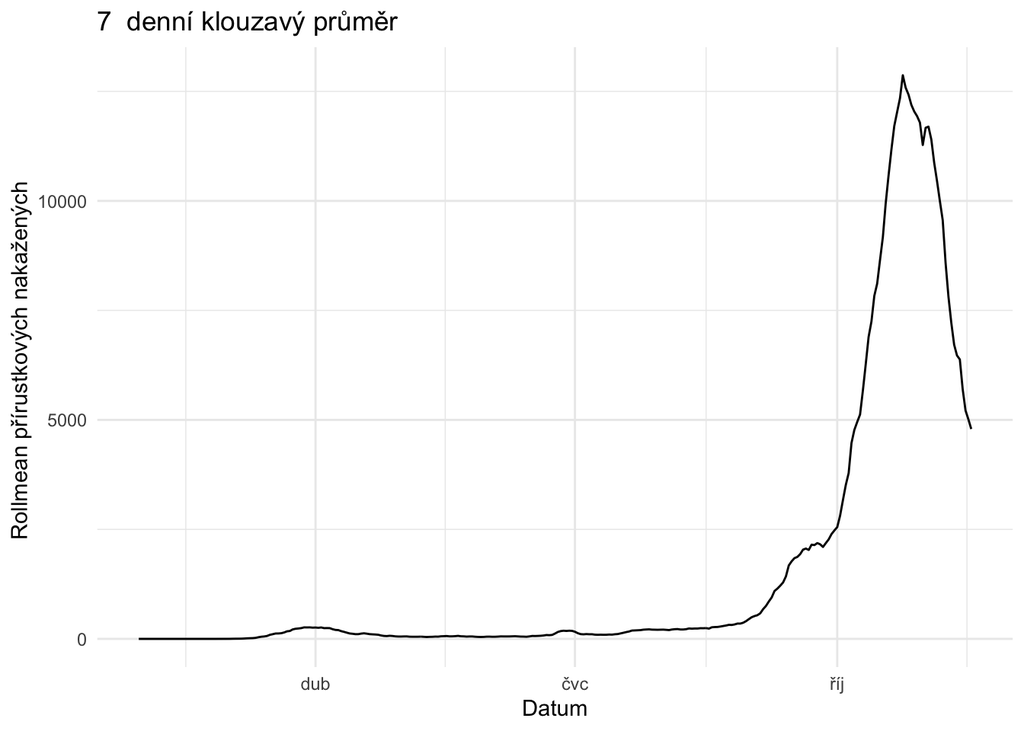

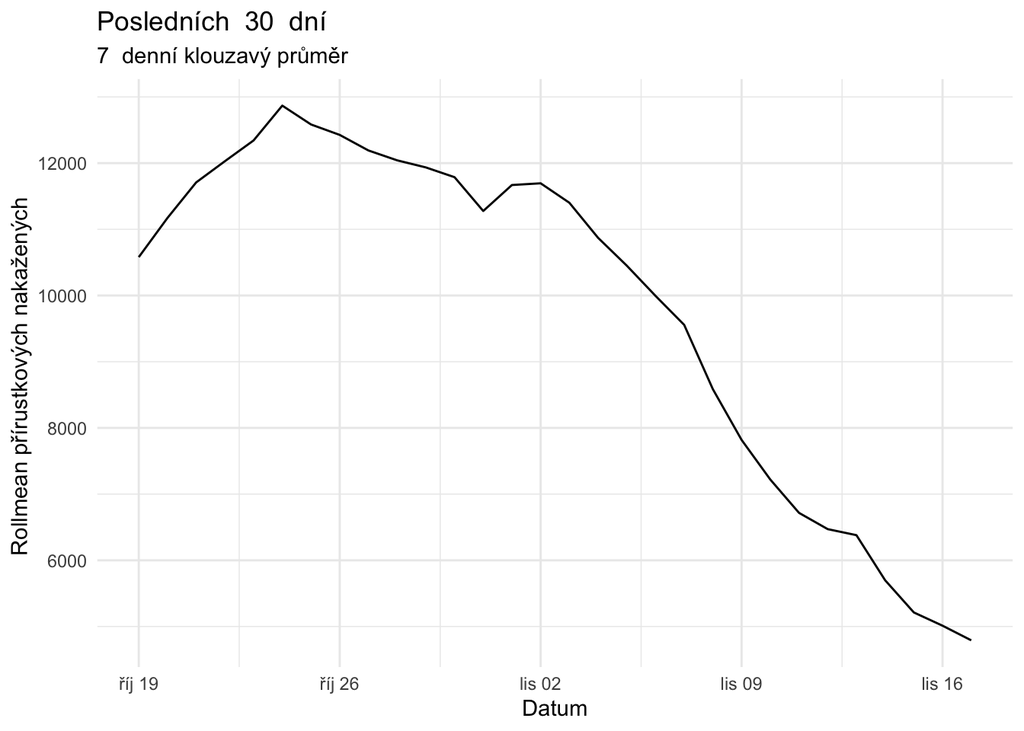

## Podíl pozitivních testů

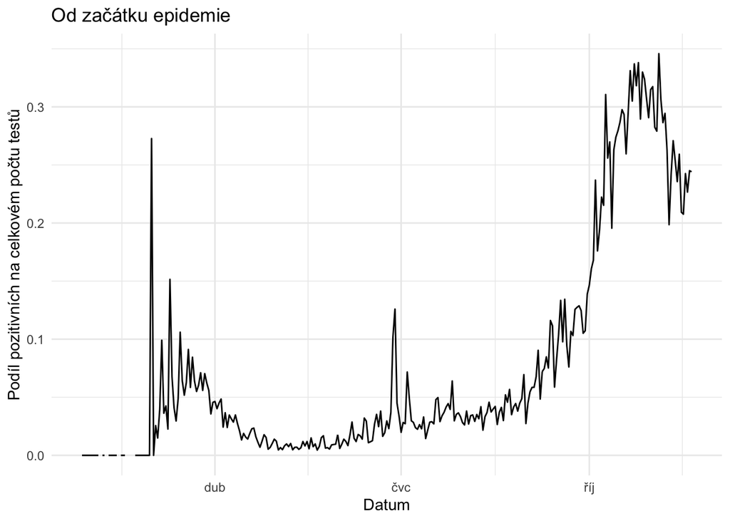

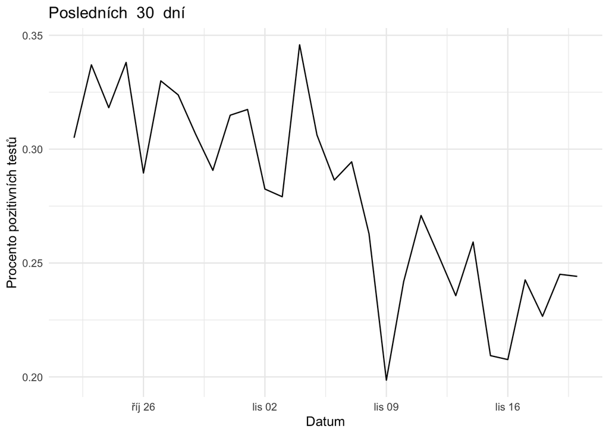

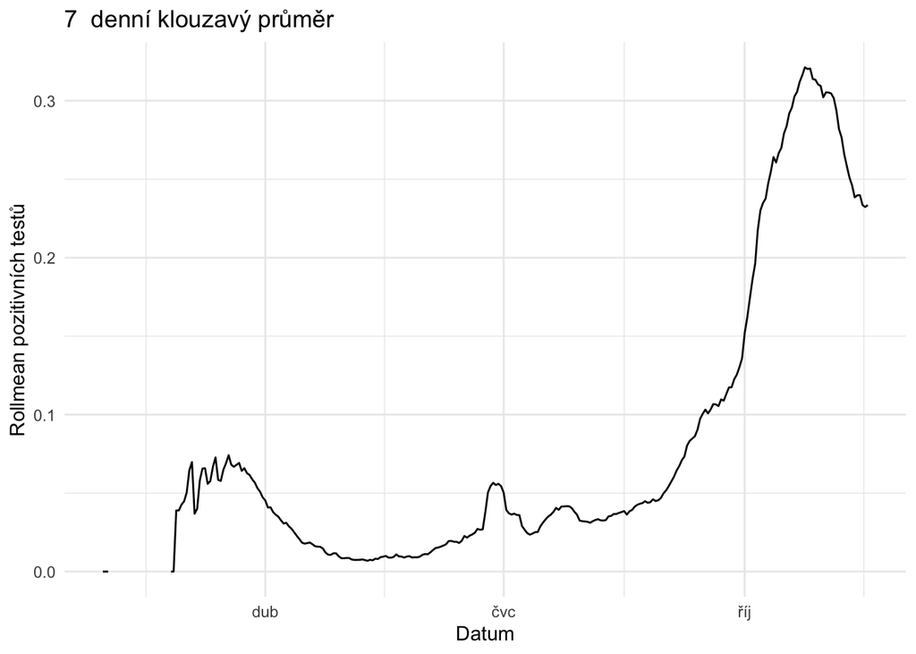

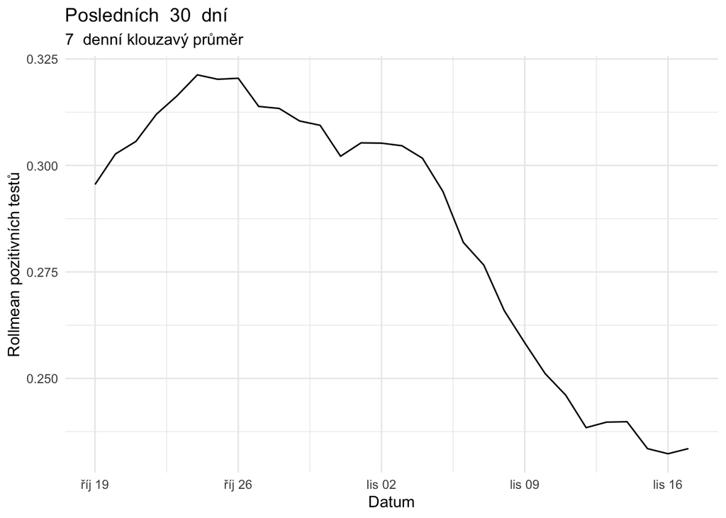

Podíl pozitivních testů na celkovém počtu od začátku epidemie je `16.782` %.

Podíl pozitivních testů na celkovém počtu za posledních 30 dní je `28.638` %.

# Modely

## Linearní model

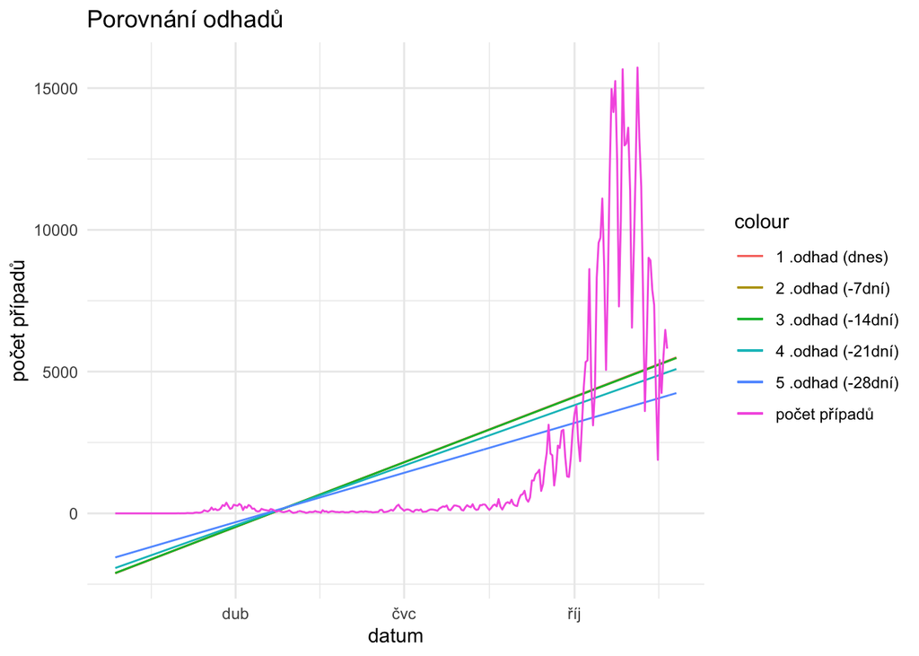

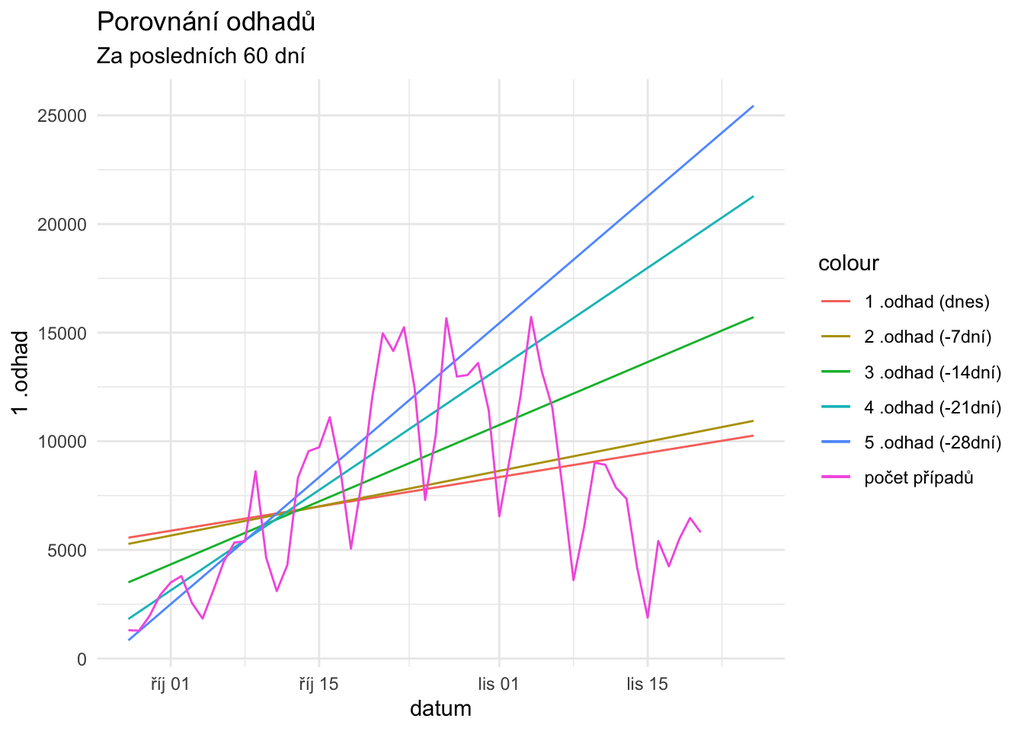

### Data (Lineární model)

#### Od začátku epidemie

Podle lineárního modelu bychom tímto tempem měli dne `2020-11-25` podle

- 1. odhadu `5502` nakažených denně
- 2. odhadu `5480` nakažených denně
- 3. odhadu `5483` nakažených denně
- 4. odhadu `5091` nakažených denně
- 5. odhadu `4242` nakažených denně

#### Za posledních `60` dní

Podle lineárního modelu bychom tímto tempem měli dne `2020-11-25` podle

- 1. odhadu `10263` nakažených denně
- 2. odhadu `10942` nakažených denně
- 3. odhadu `15717` nakažených denně
- 4. odhadu `21284` nakažených denně
- 5. odhadu `25451` nakažených denně

## Kvadratický model

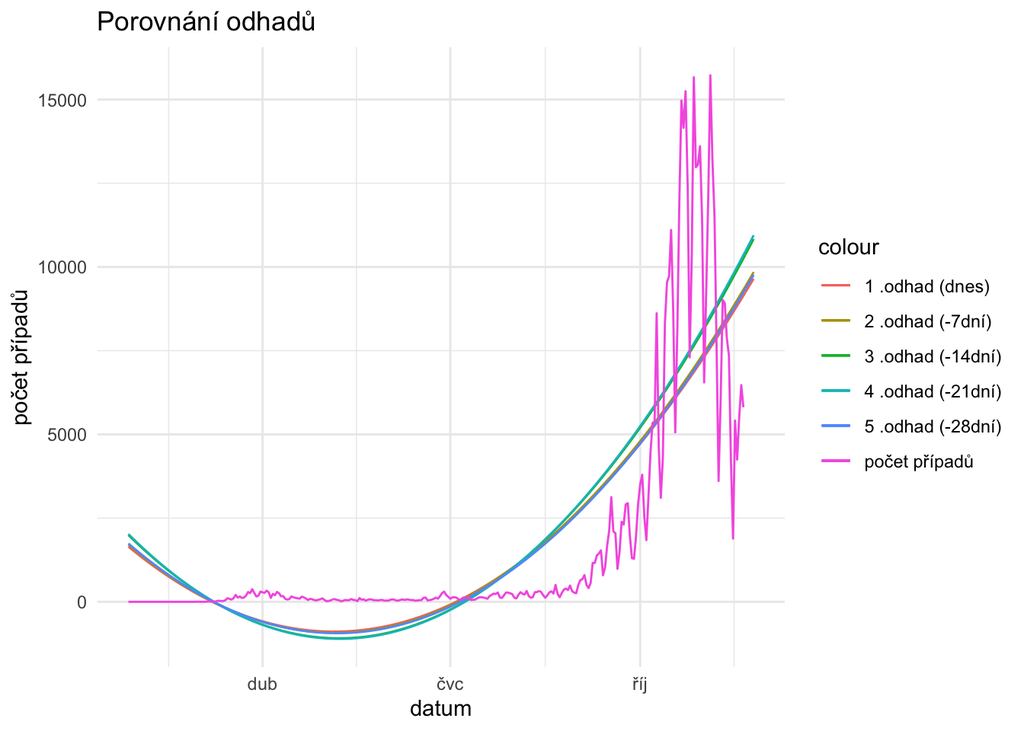

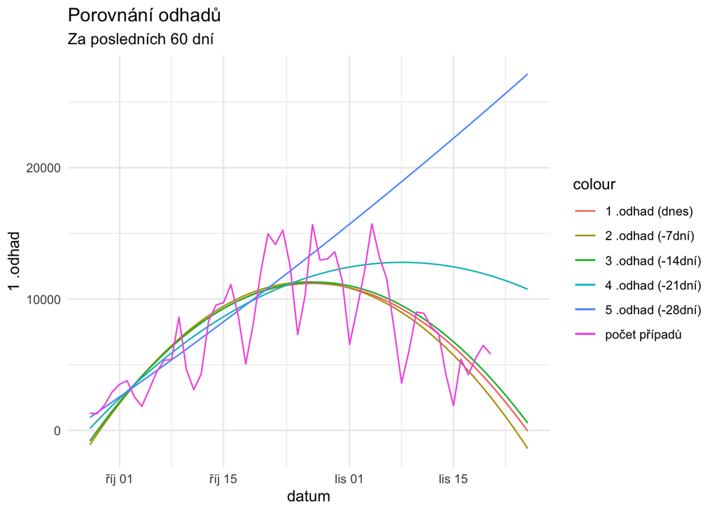

### Data (Kvadratický model)

#### Od začátku epidemie

Podle kvadratického modelu bychom tímto tempem měli dne `2020-11-25` podle

- 1. odhadu `9648` nakažených denně
- 2. odhadu `9846` nakažených denně
- 3. odhadu `10835` nakažených denně
- 4. odhadu `10947` nakažených denně
- 5. odhadu `9762` nakažených denně

#### Za posledních `60` dní

- 1. odhadu `-49` nakažených denně
- 2. odhadu `-1377` nakažených denně
- 3. odhadu `557` nakažených denně
- 4. odhadu `10748` nakažených denně
- 5. odhadu `27143` nakažených denně

## Exponential model

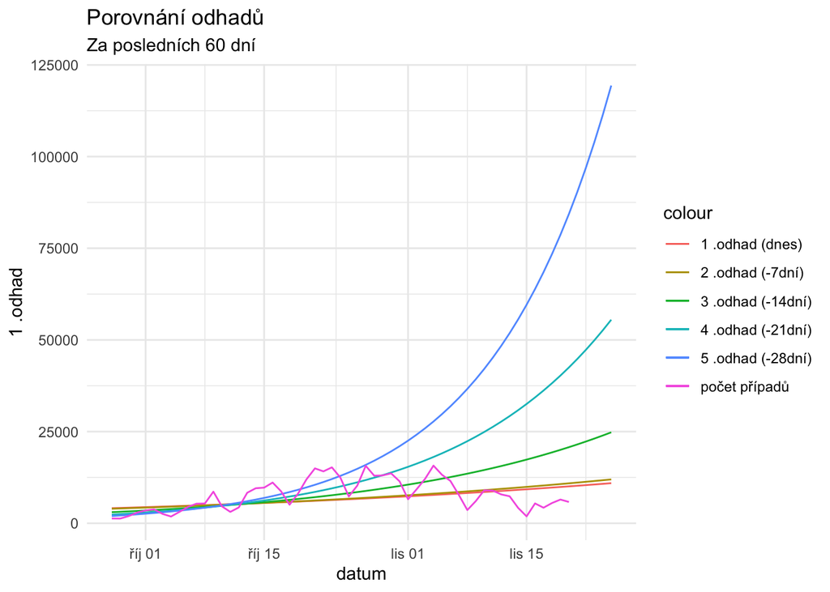

### Data (Exponential model)

#### Za posledních `60` dní

Podle exponencionálního modelu bychom tímto tempem měli dne `2020-11-25` podle

- 1. odhadu `10935` nakažených denně
- 2. odhadu `11963` nakažených denně
- 3. odhadu `24804` nakažených denně
- 4. odhadu `55508` nakažených denně
- 5. odhadu `119370` nakažených denně

Podle exponencionálního modelu bychom tímto tempem měli dnes dne `2020-11-21` podle

- 1. odhadu `10234` nakažených denně
- 2. odhadu `11100` nakažených denně
- 3. odhadu `21506` nakažených denně
- 4. odhadu `44826` nakažených denně
- 5. odhadu `90408` nakažených denně

# Informace

Update proběhl `2020-11-21 20:05:06`.

Poslední data jsou z `2020-11-20` ze stránek ministerstva zdravotnictví ČR (https://onemocneni-aktualne.mzcr.cz/covid-19)